# Applied Computational Methods for Social Sciences

Lecture 13: Geometric Operations with Vectors — Centroids, Distances, Dissolving, Buffers

Bogdan G. Popescu

bogdan.popescu@johncabot.edu

John Cabot University

## What You’ll Learn Today

1. **Geometric calculations**: areas, unit conversions, and distances
2. Calculating **centroids** of polygons
3. **Buffers** and **dissolving** polygons
4. **Casting** geometries between types
5. Measuring **line density** by polygon (railways per province)

By the end, you’ll be able to answer “how far, how big, how dense” questions with vector data.

## Intro

The main goals for today include:

- Learn more about spatial funnction in the `sf` package
- perform geometric calculations: areas, change units
- calculating centroids and distances
- making buffers and dissolving polygons
- casting lines
- intersecting polygons and calculating line density by polygons

## Geometric Calculations

Geometric Calculations can be divided into three groups based on their output:

- **Numeric**: calculating areas, length, or polygon areas
- **Logical**: whether feature A intersects feature B
- **Spatial**: creating polygon centroids, buffers, or intersection area

## Numeric Geometric Calculations

There are several functions pertaining to the `sf` package that are helpful to calculate numeric geometric properties:

- Functions applicable to **individual geometries**
  - `st_box` - to calculate the bounding box coordinates
  - `st_area` - to calculate the area of a feature
  - `st_length` - to calculate length of lines or perimeters
  - `st_dimension` - returns a numeric vector with 0 for points, 1 for lines, 2 for surfaces and `NA` for empty geometries.
- Functions applicable to **geometry pairs**
  - `st_distance` - to calculate distance between units

## Numeric Geometric Calculations

[Download](https://www.dropbox.com/scl/fo/5i41pl05yuo5602ytds9j/h?rlkey=yezz3ty17u49p08wtnxdoqk4u&dl=0) or copy the shape files from the previous lecture for Spain: gadm41_ESP_shp

Put them in a data folder under the relevant week.

Read the level-2 shapefiles:

```r
#Step0: Loading libraries
library(sf)
library(ggplot2)
sf_use_s2(FALSE)
#Step1: Reading Spain borders at level 0 and 2
esp0 <- st_read(dsn="./data/gadm41_ESP_shp/gadm41_ESP_0.shp", quiet = TRUE)
esp2 <- st_read(dsn="./data/gadm41_ESP_shp/gadm41_ESP_2.shp", quiet = TRUE)
#Step2: Simplifying the shapefile for easier plotting
esp0<-st_simplify(esp0, dTolerance=0.01)
esp2<-st_simplify(esp2, dTolerance=0.01)
#Step3: Selecting only one variable
esp2b<-subset(esp2, select = c("NAME_2"))
```

## Numeric Geometric Calculations: Area

We can use `st_area` to calculate the area of the provinces in Spain

```r
#Calculating the area
esp2b$area<-st_area(esp2b)
```

If we examine the first six entries, we see the following output:

```r
esp2b$area[1:6]
```

```
Units: [m^2]
[1]  8803257583  7430873208 13774060764 12648893283 10103977438 13476416303
```

*Meters* or *Square Meters* are the default units for area and distance calculations.

We can convert the `units` objects to other type of units such as *Square Kilometers*

```r
library(units)
esp2b$area_sqkm<-set_units(esp2b$area, 'km^2')
esp2b$area_sqkm[1:6]
```

```
Units: [km^2]
[1]  8803.258  7430.873 13774.061 12648.893 10103.977 13476.416
```

## Numeric Geometric Calculations: Area

And here is how they compare to the original calculation:

Transformation to Square Km:

```r
esp2b$area_sqkm[1:6]
```

```
Units: [km^2]
[1]  8803.258  7430.873 13774.061 12648.893 10103.977 13476.416
```

Original area:

```r
esp2b$area[1:6]
```

```
Units: [m^2]
[1]  8803257583  7430873208 13774060764 12648893283 10103977438 13476416303
```

Notice however that the two columns are not `numeric`. They are `units`.

You can see that using `str`:

```r
str(esp2b$area_sqkm)
```

```
 Units: [km^2] num [1:52] 8803 7431 13774 12649 10104 ...
```

## Numeric Geometric Calculations: Area

We can make this a numeric variable in the following way:

```r
esp2b$area_sqkm_numeric<-as.numeric(esp2b$area_sqkm)
esp2b$area_sqkm_numeric[1:6]
```

```
[1]  8803.258  7430.873 13774.061 12648.893 10103.977 13476.416
```

We can check using the following:

```r
str(esp2b$area_sqkm_numeric)
```

```
 num [1:52] 8803 7431 13774 12649 10104 ...
```

## Numeric Geometric Calculations: Area

We can map the district area by using the following steps:

```r
#Step1: Turning multipolygons into polygons
esp0b = st_cast(esp0,"POLYGON")
#Step2: Calculating area
esp0b$area<-st_area(esp0b)
#Step3: Selecting the largest polygon
esp0b<-subset(esp0b, area==max(area))
#Step4: Creating a box around the polygon
bbox <- st_bbox(esp0b)

#Step5: Extracting min and max latitudes and longitudes
min_lat_y <- bbox["ymin"]
max_lat_y <- bbox["ymax"]
min_lon_x <- bbox["xmin"]
max_lon_x <- bbox["xmax"]

error<-0.05

ggplot(esp2b, aes(fill=area_sqkm_numeric)) +
  geom_sf() +
  geom_sf_text(aes(label = NAME_2), colour = "white", size=2)+
  theme_void() +
    coord_sf(xlim = c(min_lon_x - error, max_lon_x + error),
           ylim = c(min_lat_y - error, max_lat_y + error))+
  scale_fill_viridis_c(option = "viridis")
```

## Numeric Geometric Calculations: Area

And here is the output:

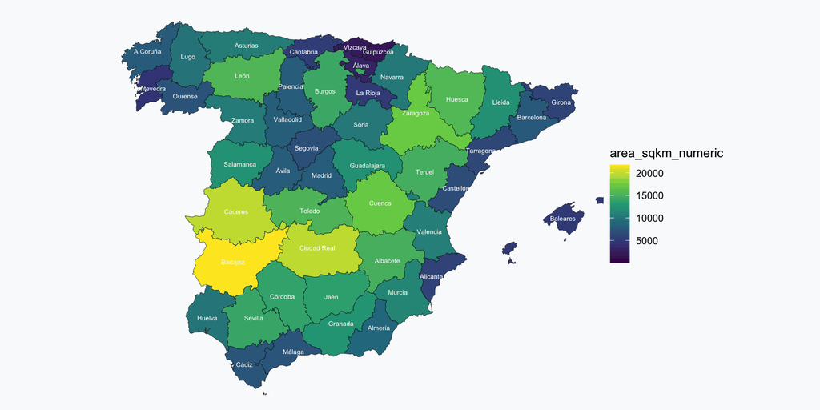

## Numeric Geometric Calculations: Distance

We can calculate the distance between two features using `st_distance`.

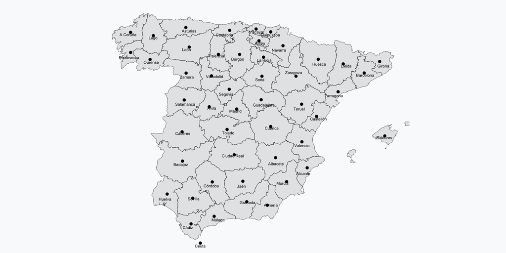

## Numeric Geometric Calculations: Distance

Let’s say that we want to calculate the distance between Avila and Valencia

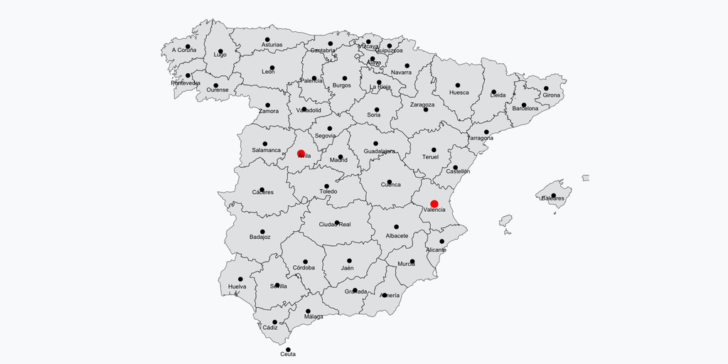

## Numeric Geometric Calculations: Distance

To do this, we can simply do:

Step 1: Calculating centroids

```r
# Calculating polygon centroids
esp2_ctr<-st_centroid(esp2b)
```

This is how polygons translate into centroids

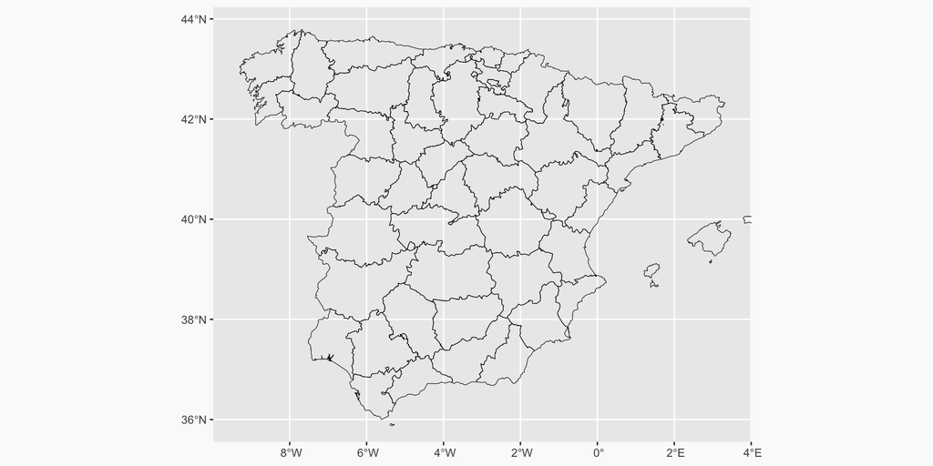

```r
ggplot()+
  geom_sf(data=esp2b, color="black", fill=NA)+
      coord_sf(xlim = c(min_lon_x - error, max_lon_x + error),
           ylim = c(min_lat_y - error, max_lat_y + error))
```

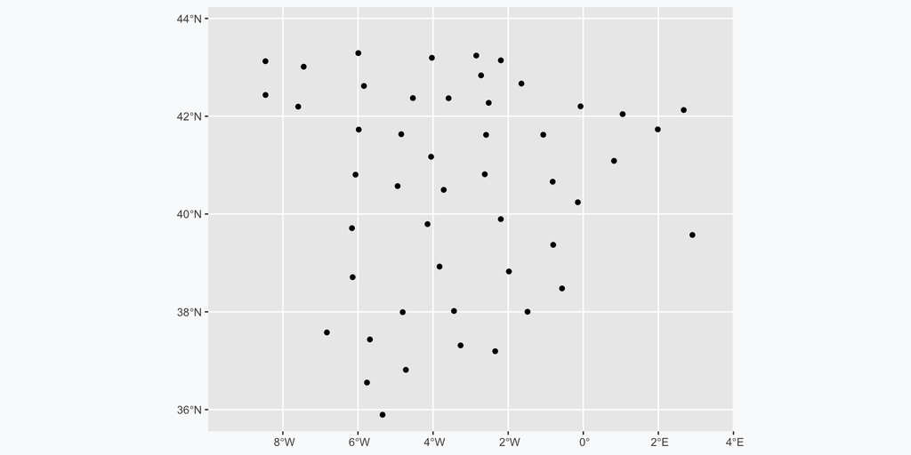

```r
ggplot()+
  geom_sf(data=esp2_ctr, color="black", fill=NA)+
      coord_sf(xlim = c(min_lon_x - error, max_lon_x + error),
           ylim = c(min_lat_y - error, max_lat_y + error))
```

## Numeric Geometric Calculations: Distance

Step 2: Selecting the place of interest

```r
place_int<-subset(esp2_ctr, NAME_2=="Valencia" | NAME_2=="Ávila")
```

```r
# Numeric Geometric Calculations: Distance
dist <- st_distance(place_int)
```

The result is `matrix` of `units` values

```r
dist
```

```
Units: [m]
         [,1]     [,2]
[1,]      0.0 378251.8
[2,] 378251.8      0.0
```

## Numeric Geometric Calculations: Distance

Rows refer to origins and columns refer to destination

So the distance between Avila and Avila is 0 meters.

The distance between Valencia and Valencia is 0 meters

## Numeric Geometric Calculations: Distance

We can of course calculate distances among multiple points

```r
#Step1: Selecting the regions of interest
place_int2<-subset(esp2_ctr, NAME_2=="Valencia" | NAME_2=="Ávila" | NAME_2=="Madrid")
#Step2: Mapping centroids onto polygons
ggplot() +
  geom_sf(data= esp2b) +
  geom_sf(data= esp2_ctr, color="black") +
  geom_sf(data= place_int2, color="red", size=3) +
  geom_sf_text(data=esp2_ctr, aes(label = NAME_2), colour = "black", size=2, hjust=0.5, vjust=1.5)+
  theme_void() +
    coord_sf(xlim = c(min_lon_x - error, max_lon_x + error),
           ylim = c(min_lat_y - error, max_lat_y + error))
```

## Numeric Geometric Calculations: Distance

We can of course calculate distances among multiple points

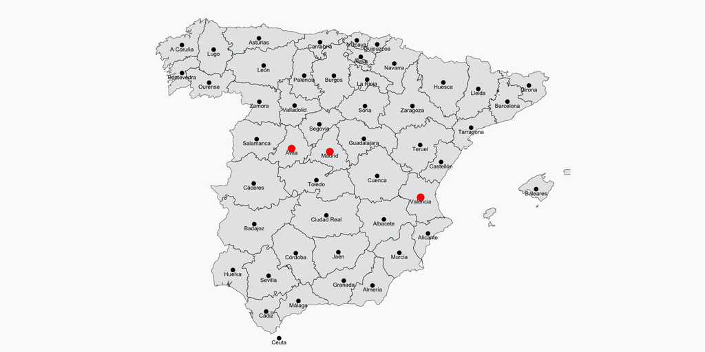

## Numeric Geometric Calculations: Distance

We can now calculate the distance

```r
# Numeric Geometric Calculations: Distance
dist <- st_distance(place_int2)
```

The result is `matrix` of `units` values

```r
dist
```

```
Units: [m]
         [,1]     [,2]     [,3]
[1,]      0.0 104415.2 378251.8
[2,] 104415.2      0.0 278729.0
[3,] 378251.8 278729.0      0.0
```

## Numeric Geometric Calculations: Distance

The result is `matrix` of `units` values

```r
dist
```

```
Units: [m]
         [,1]     [,2]     [,3]
[1,]      0.0 104415.2 378251.8
[2,] 104415.2      0.0 278729.0
[3,] 378251.8 278729.0      0.0
```

## Numeric Geometric Calculations: Distance

Rows refer to origins and columns refer to destination

So the distance between Avila and Avila is 0 meters.

The distance between Madrid and Madrid is 0 meters

And so on…

## Numeric Geometric Calculations: Distance

Just like before, we can set the units to km

```r
library(units)
dist2<-set_units(dist, 'km')
dist2
```

```
Units: [km]
         [,1]     [,2]     [,3]
[1,]   0.0000 104.4152 378.2518
[2,] 104.4152   0.0000 278.7290
[3,] 378.2518 278.7290   0.0000
```

## Numeric Geometric Calculations

Thus, we have covered examples of numeric geometric calculations

We now move to **logical geometric calculations**

## Logical Geometric Calculations

There are are a variety geometric calculations including:

- `st_contains_properly`
- `st_contains`
- `st_covered_by`
- `st_covers`
- `st_crosses`
- `st_disjoint`
- `st_equals_exact`
- `st_equals`
- `st_intersects`
- `st_is_within_distance`
- `st_overlaps`
- `st_touches`
- `st_within`

To see more details on what they do, check out the [Package ‘sf’ Manual](https://cran.r-project.org/web/packages/sf/sf.pdf)!

## Spatial Geometric Calculations

The `sf` package also provides common geometry operation functions

- `st_centroid`
- `st_buffer`
- `st_convex_hull`
- `st_voronoi`
- `st_sample`

## Spatial Geometric Calculations

## Spatial Geometric Calculations

## Spatial Geometric Calculations

## Spatial Geometric Calculations

## Spatial Geometric Calculations

## Spatial Geometric Calculations: Centroids

A **centroid** is the geometric center of the geometry, represented by one point.

For example, we have already calculated polygon centroids

```r
#Step1: Calculating centroids
esp2_ctr<-st_centroid(esp2)
#Step2: Mapping centroids onto polygons
ggplot() +
  geom_sf(data= esp2) +
  geom_sf(data= esp2_ctr, color="black") +
  geom_sf_text(data=esp2, aes(label = NAME_2), colour = "black", size=2, hjust=0.5, vjust=1.5)+
  theme_void() +
    coord_sf(xlim = c(min_lon_x - error, max_lon_x + error),
           ylim = c(min_lat_y - error, max_lat_y + error))
```

## Spatial Geometric Calculations: Centroids

A **centroid** is the geometric center of the geometry, represented by one point.

For example, we have already calculated polygon centroids

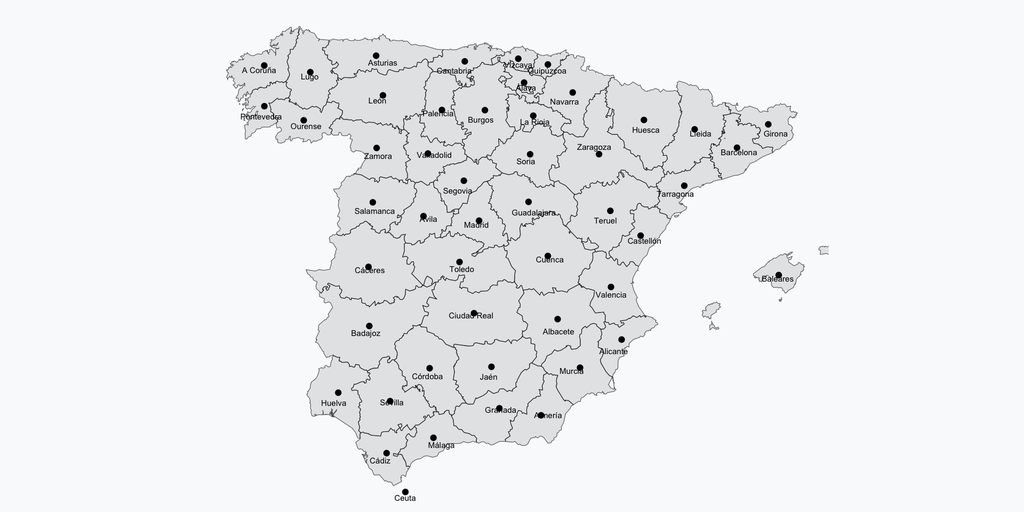

## Spatial Geometric Calculations: Combining and Dissolving

The `st_combine` and `st_union` functions can be used to combine multiple geometries into a single geometry

`st_combine` combines geometries into one. `st_union` dissolves internal borders

We can easily see the difference below:

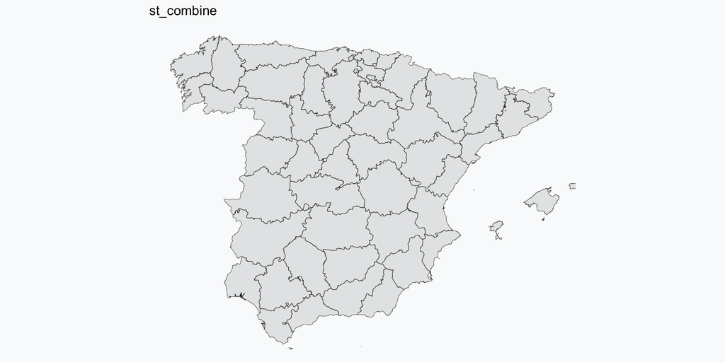

```r
esp1 <- st_read(dsn="./data/gadm41_ESP_shp/gadm41_ESP_2.shp", quiet = TRUE)
p1<-ggplot()+
  geom_sf(data=st_combine(esp1))+theme_void() +
    coord_sf(xlim = c(min_lon_x - error, max_lon_x + error),
           ylim = c(min_lat_y - error, max_lat_y + error))+
  ggtitle("st_combine")
p1
```

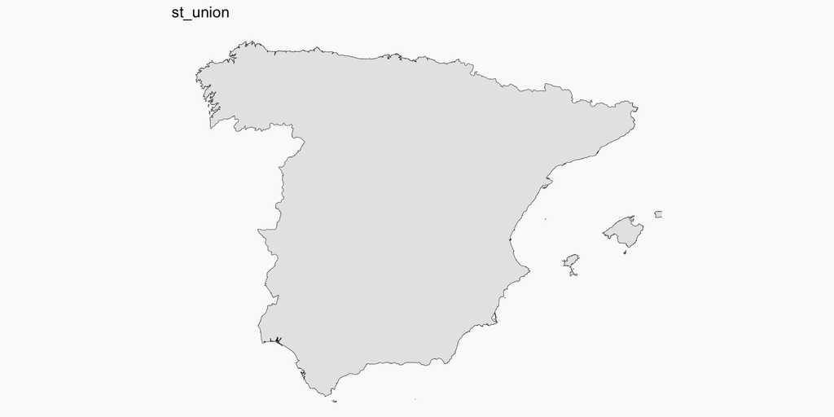

```r
p2<-ggplot()+
  geom_sf(data=st_union(esp1))+theme_void() +
    coord_sf(xlim = c(min_lon_x - error, max_lon_x + error),
           ylim = c(min_lat_y - error, max_lat_y + error))+
    ggtitle("st_union")

p2
```

## Spatial Geometric Calculations

We can also see their attribute table:

Original geometry:

```r
head(esp1,  n=3)
```

```
Simple feature collection with 3 features and 13 fields
Geometry type: MULTIPOLYGON
Dimension:     XY
Bounding box:  xmin: -6.473472 ymin: 35.93736 xmax: -1.630006 ymax: 38.72911
Geodetic CRS:  WGS 84
      GID_2 GID_0 COUNTRY   GID_1    NAME_1 NL_NAME_1  NAME_2 VARNAME_2
1 ESP.1.1_1   ESP   Spain ESP.1_1 Andalucía        NA Almería        NA
2 ESP.1.2_1   ESP   Spain ESP.1_1 Andalucía        NA   Cádiz        NA
3 ESP.1.3_1   ESP   Spain ESP.1_1 Andalucía        NA Córdoba        NA
  NL_NAME_2    TYPE_2 ENGTYPE_2 CC_2   HASC_2                       geometry
1        NA Provincia  Province   04 ES.AN.AM MULTIPOLYGON (((-3.030694 3...
2        NA Provincia  Province   11 ES.AN.CD MULTIPOLYGON (((-5.841249 3...
3        NA Provincia  Province   14 ES.AN.CO MULTIPOLYGON (((-4.248001 3...
```

## Spatial Geometric Calculations

There are no substantial differences in terms of attributes:

`st_combine` geometry

```r
head(st_combine(esp1), n=3)
```

```
Geometry set for 1 feature
Geometry type: MULTIPOLYGON
Dimension:     XY
Bounding box:  xmin: -18.16153 ymin: 27.63736 xmax: 4.328195 ymax: 43.79153
Geodetic CRS:  WGS 84
```

`st_union` geometry

```r
head(st_union(esp1),  n=3)
```

```
Geometry set for 1 feature
Geometry type: MULTIPOLYGON
Dimension:     XY
Bounding box:  xmin: -18.16153 ymin: 27.63736 xmax: 4.328195 ymax: 43.79153
Geodetic CRS:  WGS 84
```

## Spatial Geometric Calculations

Calculating the distance between Ávila and Valencia

```r
#Step1: Subsetting the cities
avila <- subset(esp1, NAME_2 == 'Ávila')
valencia <- subset(esp1, NAME_2 == 'Valencia')

#Step2: Union
#This is necessary for later when we use st_combine
avila <- st_union(avila)
valencia <- st_union(valencia)

#Step3: Calculating centroids
avila_ctr = st_centroid(avila)
valencia_ctr = st_centroid(valencia)

#Step4: Calculating distance
d = st_distance(avila_ctr, valencia_ctr)
d
```

```
Units: [m]
         [,1]
[1,] 378281.9
```

```r
# Converting to km
set_units(d, 'km')
```

```
Units: [km]
         [,1]
[1,] 378.2819
```

## Spatial Geometric Calculations

Mapping the centers

```r
ggplot()+
  geom_sf(data=esp2)+
  geom_sf(data=avila_ctr, color = "red", size=3)+
  geom_sf(data=valencia_ctr, color = "red", size=3)+
      theme_void() +
    coord_sf(xlim = c(min_lon_x - error, max_lon_x + error),
           ylim = c(min_lat_y - error, max_lat_y + error))
```

## Spatial Geometric Calculations

Mapping the centers

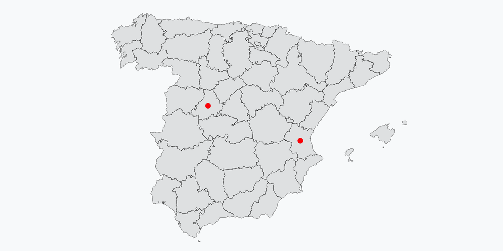

## Spatial Geometric Calculations

We can use `st_combine` to transform the points into a single `MULTIPOINT` geometry.

`st_combine` is similar to `st_union` but only combines and does not dissolve

```r
p <- c(avila_ctr, valencia_ctr)
p <- st_combine(p)
p
```

```
Geometry set for 1 feature
Geometry type: MULTIPOINT
Dimension:     XY
Bounding box:  xmin: -4.945356 ymin: 39.37033 xmax: -0.8009094 ymax: 40.57105
Geodetic CRS:  WGS 84
```

## Geometry Casting

We can use `st_cast` to draw a line between the two points

```r
l = st_cast(p, 'LINESTRING')
l
```

```
Geometry set for 1 feature
Geometry type: LINESTRING
Dimension:     XY
Bounding box:  xmin: -4.945356 ymin: 39.37033 xmax: -0.8009094 ymax: 40.57105
Geodetic CRS:  WGS 84
```

We can also visualize it:

```r
ggplot()+
  geom_sf(data=esp2)+
  geom_sf(data=avila_ctr, color = "red", size=3)+
  geom_sf(data=valencia_ctr, color = "red", size=3)+
  geom_sf(data=l, color = "red")+
      theme_void() +
    coord_sf(xlim = c(min_lon_x - error, max_lon_x + error),
           ylim = c(min_lat_y - error, max_lat_y + error))
```

## Geometry Casting

We can use `st_cast` to draw a line between the two points

```r
l = st_cast(p, 'LINESTRING')
l
```

```
Geometry set for 1 feature
Geometry type: LINESTRING
Dimension:     XY
Bounding box:  xmin: -4.945356 ymin: 39.37033 xmax: -0.8009094 ymax: 40.57105
Geodetic CRS:  WGS 84
```

We can also visualize it:

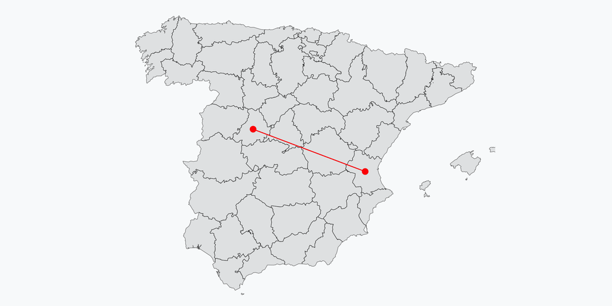

## Buffers

Another type of operation is buffer

`st_buffer` calculates buffers - polygons encompassing all points up to the specified distance from a given geometry.

We can for example calculate 250km buffers around Avila and Valencia.

To be precise about our distances, we will use [EPSG codes](https://epsg.io)

```r
# Transform your data to a suitable projected CRS that uses meters as units
# For example, you can use a UTM zone that covers your area of interest
# Here, I'm assuming your data is around Avila, Spain, so I'm using UTM zone 30N (EPSG:2062)
# See https://epsg.io/ and look for Spain
# You should choose an appropriate UTM zone for your data. Note that otherwise, this would be in degrees
#Step1: Using the relevant CRS to calculate distances in meters
avila_ctr_sp <- st_transform(avila_ctr, crs = 2062)
valencia_ctr_sp <- st_transform(valencia_ctr, crs = 2062)

#Step2: Creating the buffer at 250km. Note that unit is in meters: st_crs(avila_ctr_sp) - LENGTHUNIT under Datum
avila_250 = st_buffer(avila_ctr_sp, dist = 250000)
valencia_250 = st_buffer(valencia_ctr_sp, dist = 250000)

#Step3: Going back to the original crs in degrees
avila_250 <- st_transform(avila_250, crs = st_crs(esp2))
valencia_250 <- st_transform(valencia_250, crs = st_crs(esp2))
```

## Buffers

And this is how we plot the shape file for the buffers that we have just created:

```r
ggplot()+
  geom_sf(data=esp2)+
  geom_sf(data=avila_ctr, color = "red", size=3)+
  geom_sf(data=valencia_ctr, color = "red", size=3)+
  geom_sf(data=avila_250, color = "red", fill=NA)+
  geom_sf(data=valencia_250, color = "red", fill=NA)+
  theme_void() +
  coord_sf(xlim = c(min_lon_x - error, max_lon_x + error),
           ylim = c(min_lat_y - error, max_lat_y + error))
```

## Buffers

And this is what it looks like:

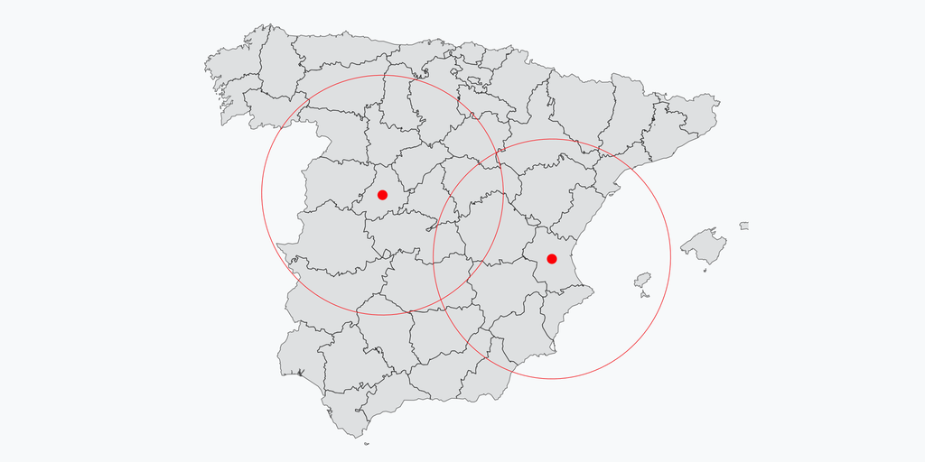

## Geometry Difference from Pairs

There are four geometry-generating functions that operate on pairs of input geometries:

- `st_intersection`
- `st_difference`
- `st_sym_difference`
- `st_union`

## Geometry Difference from Pairs

## Geometry Difference from Pairs

## Geometry Difference from Pairs

## Geometry Difference from Pairs

## Geometry Difference from Pairs

## Geometry Difference from Pairs: union

We can do this in the following way:

```r
union_area<-st_union(avila_250, valencia_250)

ggplot()+
  geom_sf(data=esp2)+
  geom_sf(data=avila_ctr, color = "red", size=3)+
  geom_sf(data=valencia_ctr, color = "red", size=3)+
  geom_sf(data=union_area, color = "red", fill=NA)+
  theme_void() +
    coord_sf(xlim = c(min_lon_x - error, max_lon_x + error),
           ylim = c(min_lat_y - error, max_lat_y + error))
```

## Geometry Difference from Pairs: union

We can do this in the following way:

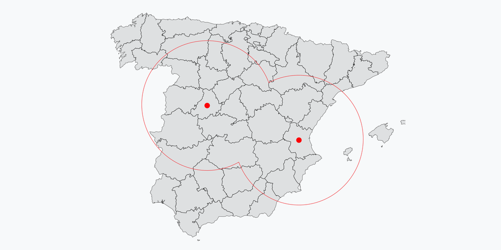

## Geometry Difference from Pairs: union

Remember that `st_union` can also be applied to an individual layer,

This returns a dissolved union of all geometries:

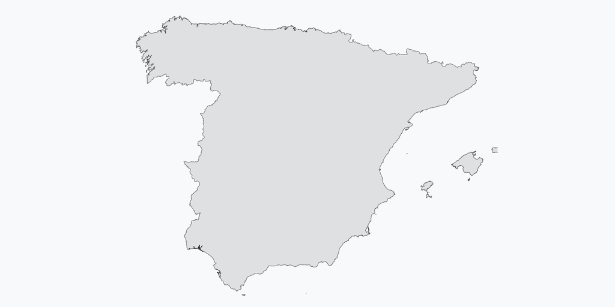

## Vector layer aggregation

Sometimes, we may not want to dissolve all features into a single geometry

Sometimes, we may want to dissolve by an attribute

## Vector layer aggregation

Let us assume that we did not have the polygons for provinces in Spain.

And we had instead polygons for sub-provinces.

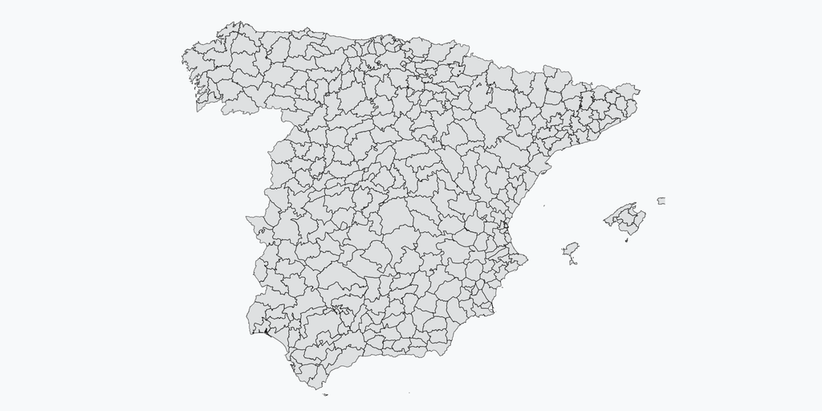

```r
esp3 <- st_read(dsn="./data/gadm41_ESP_shp/gadm41_ESP_3.shp", quiet = TRUE)
ggplot()+
  geom_sf(data=esp3)+
  theme_void() +
  coord_sf(xlim = c(min_lon_x - error, max_lon_x + error),
           ylim = c(min_lat_y - error, max_lat_y + error))
```

## Vector layer aggregation

We can visualize all the provinces by color.

```r
ggplot()+
  geom_sf(data=esp3, aes(fill=NAME_2))+
  theme_void() +
  coord_sf(xlim = c(min_lon_x - error, max_lon_x + error),
           ylim = c(min_lat_y - error, max_lat_y + error))
```

## Vector layer aggregation

We can visualize all the provinces by color.

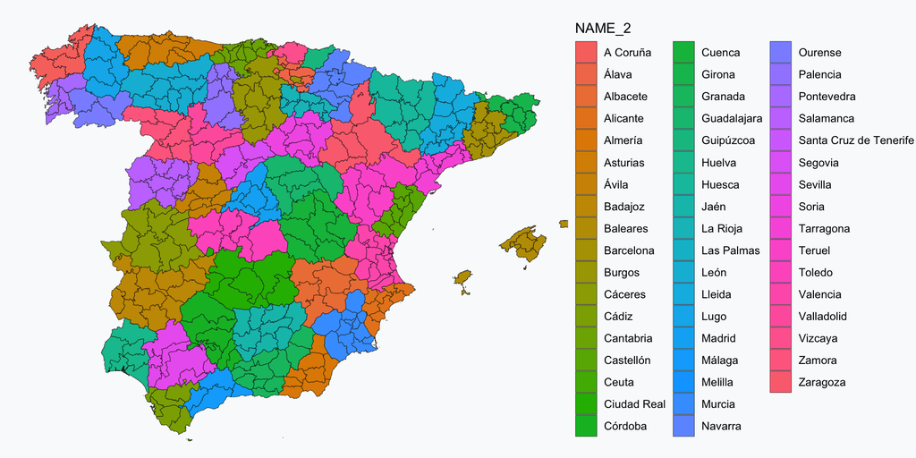

## Vector layer aggregation

We can thus aggregate by NAME_2 - the variable that defines the name of the province

```r
library(dplyr)
esp3 <- st_read(dsn="./data/gadm41_ESP_shp/gadm41_ESP_3.shp", quiet = TRUE)
esp3c<-esp3 %>%
  group_by(NAME_2) %>%
  summarize()
```

And then map it out:

```r
ggplot()+
  geom_sf(data=esp3c)+
  theme_void() +
  coord_sf(xlim = c(min_lon_x - error, max_lon_x + error),
           ylim = c(min_lat_y - error, max_lat_y + error))
```

## Vector layer aggregation

We can also aggregate by NAME_2

```r
esp3 <- st_read(dsn="./data/gadm41_ESP_shp/gadm41_ESP_3.shp", quiet = TRUE)
esp3c<-esp3 %>%
  group_by(NAME_2) %>%
  summarize()
```

And then map it out:

```r
ggplot()+
  geom_sf(data=esp3c)+
  theme_void() +
  coord_sf(xlim = c(min_lon_x - error, max_lon_x + error),
           ylim = c(min_lat_y - error, max_lat_y + error))
```

## Vector layer aggregation

We can thus aggregate by NAME_2

```r
esp3c<-esp3 %>%
  group_by(NAME_2) %>%
  summarize()
```

And then map it out:

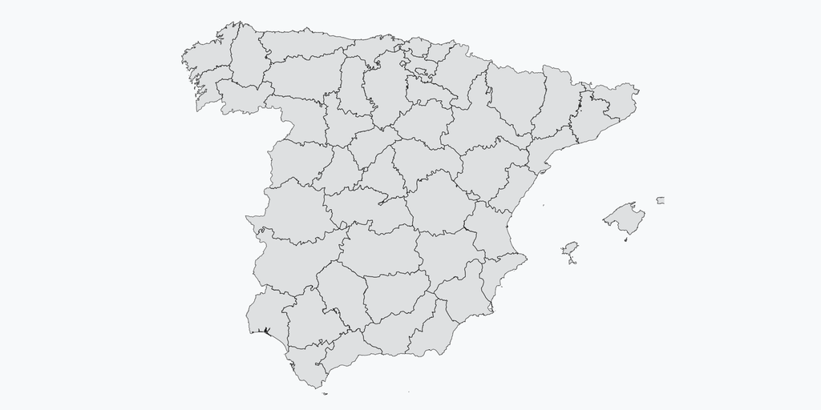

## Vector layer aggregation

Here is what non-aggregated vs. aggregated at NAME_2 level look like:

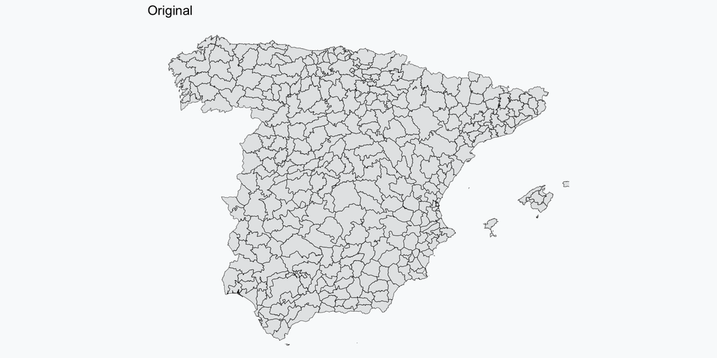

```r
ggplot()+
  geom_sf(data=esp3)+
  theme_void() +
  coord_sf(xlim = c(min_lon_x - error, max_lon_x + error),
           ylim = c(min_lat_y - error, max_lat_y + error))+
  ggtitle("Original")
```

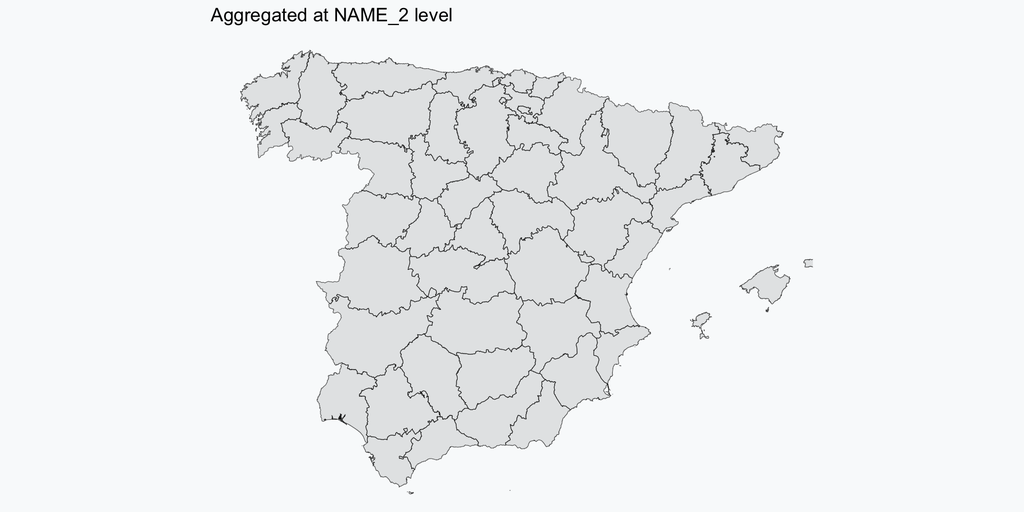

```r
esp3c<-esp3 %>%
  group_by(NAME_2) %>%
  summarize()

ggplot()+
  geom_sf(data=esp3c)+
  theme_void() +
  coord_sf(xlim = c(min_lon_x - error, max_lon_x + error),
           ylim = c(min_lat_y - error, max_lat_y + error))+
  ggtitle("Aggregated at NAME_2 level")
```

## Vector layer aggregation

A common operation is to calculate density of lines within polygons

[Download railways from Spain](https://www.dropbox.com/scl/fo/tkrpn4a47zjywhfbkkw49/h?rlkey=3keawjf3xjqvkc9n2jrsna907&dl=0)

For example, we would be interested in calculating density of railways within provinces

```r
#Step1: Reading the polylines
rails <- st_read(dsn="./data/europe-railways-shape/railways_esp.shp", quiet = TRUE)
```

This an sf file with many rows: 6128

```r
#Counting no. of rows
nrow(rails)
```

```
[1] 6128
```

```r
#Adding a unique number for each line
rails$no<-rownames(rails)
```

## Vector layer aggregation

We can see the many different disjointed lines below

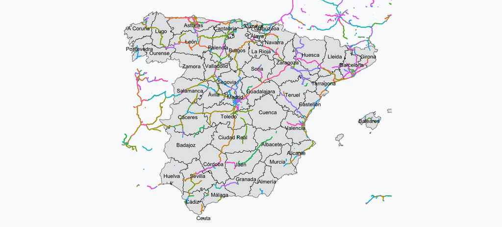

```r
ggplot() +
  geom_sf(data=esp2) +
  geom_sf(data=rails, aes(color=no))+
  guides(color = "none")+
  geom_sf_text(data=esp2, aes(label = NAME_2), colour = "black", size=2)+
  theme_void() +
    coord_sf(xlim = c(min_lon_x - error, max_lon_x + error),
           ylim = c(min_lat_y - error, max_lat_y + error))
```

## Vector layer aggregation

We clearly do not need that many rows. We can aggregate all our railways

```r
#Step2: Creating a unique variable to merge all the lines
rails$all<-"all_rails"

#Step3: Merging the lines
rails2 <- rails %>%
  group_by(all) %>%
  summarise()
```

## Vector layer aggregation

We can now inspect the result

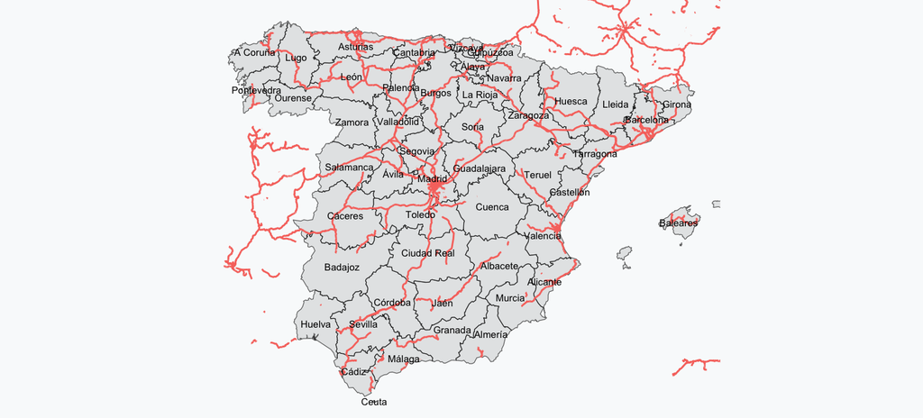

```r
ggplot() +
  geom_sf(data=esp2) +
  geom_sf(data=rails2, aes(color=all))+
  guides(color = "none")+
  geom_sf_text(data=esp2, aes(label = NAME_2), colour = "black", size=2)+
  theme_void() +
    coord_sf(xlim = c(min_lon_x - error, max_lon_x + error),
           ylim = c(min_lat_y - error, max_lat_y + error))
```

## Vector layer aggregation

We can now perform the intersection between the polylines and the polygon

```r
#Step4: Intersecting railroads with polygons
intersection <- st_intersection(rails2, esp2b)
```

The intersection has 47 observations

```r
nrow(intersection)
```

```
[1] 47
```

## Vector layer aggregation

We can now inspect the result

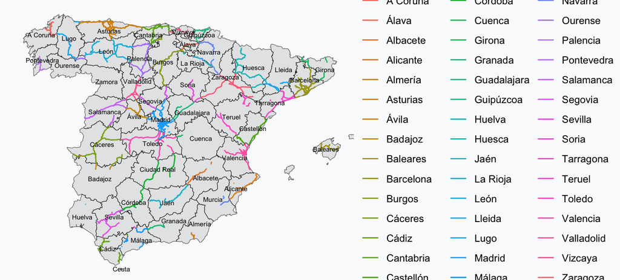

```r
ggplot() +
  geom_sf(data=esp2) +
  geom_sf(data=intersection, aes(color=NAME_2))+
  #guides(color = "none")+
  geom_sf_text(data=esp2, aes(label = NAME_2), colour = "black", size=2)+
  theme_void() +
    coord_sf(xlim = c(min_lon_x - error, max_lon_x + error),
           ylim = c(min_lat_y - error, max_lat_y + error))
```

## Vector layer aggregation

We now calculate the individual rail length per district

```r
#Step5: Calculating individual rail length and turning it into km
intersection$indiv_rail<-st_length(intersection)
intersection$indiv_rail<-set_units(intersection$indiv_rail, 'km')

#Step6: Dividing rail length by polygon area
intersection$rail_density<-intersection$indiv_rail/intersection$area_sqkm
intersection$rail_density<-as.numeric(intersection$rail_density)

#Step7: Saving only relevant variables
intersection2<-subset(intersection, select=c("NAME_2", "rail_density"))

#Step8: Dropping geometry
intersection2<-st_drop_geometry(intersection2)

#Step9: Performing a left merge
esp2c<-left_join(esp2b, intersection2, by = c("NAME_2"= "NAME_2"))
```

## Vector layer aggregation

We now calculate the individual rail length per district

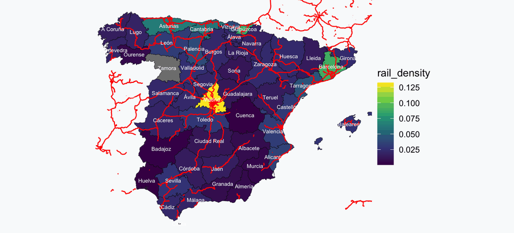

```r
#Step10: Mapping
ggplot() +
  geom_sf(data=esp2c, aes(fill=rail_density)) +
  geom_sf(data=rails2, color="red")+
  geom_sf_text(data=esp2c, aes(label = NAME_2), colour = "white", size=2)+
  theme_void() +
    coord_sf(xlim = c(min_lon_x - error, max_lon_x + error),
           ylim = c(min_lat_y - error, max_lat_y + error))+
  scale_fill_viridis_c(option = "viridis")
```

## What Have We Learned?

We have covered a variety of `sf` functions:

- perform geometric calculations: areas, changing units
- calculating distances
- calculating centroids
- making buffers and dissolving polygons
- casting lines
- calculating line density by polygons